# Constraint functions

Daniel Kaplan

Functions are a central theme of CalcZ. Modeling involves **constructing** functions to represent a situation. Integration and differentiation are **operations** that are performed on functions to produce a new function that has a desired property. Other important operations are **zero-finding** and **optimization**, both of which involve finding the input to a function that produces a desired output: output zero for zero finding, output maximal for optimization.

**Optimization** involves both a modeling phase and an operation phase. You construct an **objective function** to represent how well a goal is achieved. Then you apply operations on the objective function to locate the argmax.

We have now introduced another element into optimization: **constraints**. For instance, in the cardboard-box problem, we applied a constraint that 600 square inches of cardboard are available. In the health-care choices problem, the constraint was having $1B to spend on a mixture of interventions. In both cases, the constraint was represented by an **equation**, such as $A + B + C = \$10^9$.

It turns out to be helpful to think about constraints not as *equations* but as **functions**. We’ll tend to write such functions using the name $g$ with a subscript. For instance, the health-care constraint would be represented by a function,
$$g_{budget}(A, B, C) \equiv A + B + C$$
The cardboard area constraint function was, similarly
$$g_{area}(x, y) = y^2$$

You might have noticed this approach at work when we made the graphic showing the cardboard-box optimization. We defined a volume function $V(x, y)$ as well as a constraint function $g_area(x, y)$. By writing the constraint as a function, we could use `contour_plot()` to mark the set of points where the output of the function is 600. That is, we set `contours_at = 600`.

You can see this in the sandbox in the first set of plotting commands.

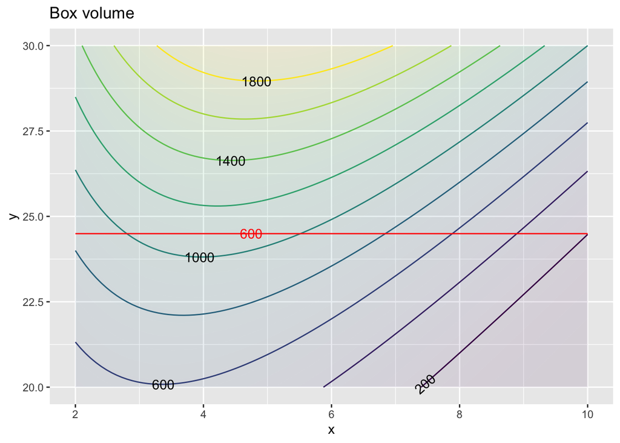

```r
V <- makeFun(x*(y - 2*x)^2 ~ x + y)
g_area <- makeFun(y^2 ~ x + y)

contour_plot(V(x, y) ~ x + y, domain(x=c(2,10), y=c(20,30))) %>%
  gf_labs(title="Box volume") %>%
  contour_plot(g_area(x, y) ~ x + y,
               filled=FALSE, contour_color = "red",
               contours_at = 600)
```

```r
# contour_plot(g_area(x, y) ~ x + y, domain(x=c(2,8), y=c(20,28))) %>%
#   gf_labs(title="Cardboard area") %>%
#   contour_plot(V(x, y) ~ x + y,
#                filled=FALSE, contour_color = "red",
#                contours_at = 1100)
#
```

There are much deeper reasons to think about constraints as **functions** than graphic-drawing convenience. One you have already seen: examining how the argmax and max would change if the constraint were seen and quantifying this with the **shadow price** (a.k.a. the Lagrange multiplier).

Another reason is multi-objective optimization where we have not just one objective function but **multiple objective functions**.

How do we find the argmax when there are multiple objective functions? As you’ve seen in the previous day’s work, the concept of “best” is sketchy when you have multiple objectives. We replaced it with the concept of “dominating” vs “dominated” policy choice." There is in general no single policy choice that dominates all others, so in multi-objective optimization there is (in general) no single argmax that works for all of the objective functions.

Instead of a mathematical **solution** to multi-objective optimization, there is a mathematical **approach** to evaluating the trade-offs inherent in multi-objective optimization. It works like this:

1. Choose **one** of the objective functions to be **the** objective function. As you’ll see, it doesn’t matter which one.
2. Treat all the other objective functions as **constraint functions**.
3. Pick reasonable output levels for each of the constraint functions. For instance, in the cardboard box constraint function, we chose an output level of 600 square inches. For the health-care budget constraint function, we chose an output level of $1B.
4. Solve the constrained optimization function you have just created.

You’re entitled at this point to scratch your head in skepticism. All we’ve done so far is to pay lip service to all but one of the objective functions by pre-specifying what the output is going to be. We’re not really optimizing over those objective functions by turning them into constraint functions. But, there’s more work to do.

5. For each of the constraint functions, calculate the **shadow-price** (a.k.a. the Lagrange multiplier). Recall that the shadow-price tells you how much the max of the single objective function would change per unit change in the constraint.

If the shadow price of a constraint is low, increase the that constraint level. If the shadow price is high, decrease that constraint level. What’s low? What’s high? That is a question of human judgment, a human value choice.

Since the multiple objectives are mutually incommensurate, there’s no purely mathematical solution to the question, “What’s low? What’s high?” But often someone knowledgeable about the situation can evaluate the trade-off. (Example: Perhaps giving up aircraft stealth can increase range. But without the stealth would you be able to perform the mission with the increased range?)

Steps (1) and (2) of this process involved choosing one objective as the objective function and setting the others as constraints. A profound mathematical result is that it doesn’t really matter which is the objective and which is the constraint. Do see this at work, go back to the sandbox and uncomment the second set of graphics commands. Here, the cardboard area is plotted as the objective function and the box volume is the constraint.

**Question tmp-1**: Which of these shapes best describes the volume constraint curve?

1. a straight line []
2. a concave-up function (+) []
3. a concave-down function []
4. a closed loop []

**Question tmp-2**: Find the argmax of the optimize-area-with-volume-constrained problem and compare it to the argmax of the optimize-volume-with-area-constrained problem. Which of these best describes the relationship between the two argmaxes?

1. they are the same (+) []
2. $x^\star$ is smaller when volume is constrained than when area is constrained []
3. $y^\star$ is smaller when volume is constrained than when area is constrained []
4. Both $x^\star$ and $y^\star$ are smaller when volume is constrained than when area is constrained []

One important setting for making judgments about shadow prices comes when the objective is something like “number of lives saved” and the constraint is money. Both of these are really objectives: save lives, save money for other purposes. The use of a budget on money—that is a constraint—is a heuristic for softening the difficult ethical choices in trading off life and money.

Of course, the budget constraint has a shadow price: the lives saved per dollar spent. Few people are comfortable equating lives and money, but any choice of budget mathematically implies a corresponding shadow price. Ideally, the high-level decision makers (that is, the people who set the budget) would compare the shadow prices implicit in their decisions and adjust accordingly. For instance, in many cities there is a department of education that has a budget for lead paint mitigation and a separate department of transportation that has a budget for pedestrian road markings. Let’s imagine that the shadow price for lead mitigation (lives per dollar) is much lower than the shadow price for pedestrian road markings (also, lives per dollar). In such a situation it would be justified to move funding from education to transportation.

Classically, you locate the argmax by differentiating the objective function and then apply zero-finding to the derivative. But there are other operations that will achieve the same aim. For example, you can differentiate the objective function to find the gradient vector and then, starting at some arbitrary initial value, change that value in the direction of the gradient. This amounts to walking uphill. Easy.

Although walking uphill sounds simple minded, it is the basis for a lot of the sophisticated computer technology for doing optimization. For instance, in machine learning, neural networks are “trained” by repeatedly presenting an input for which the desired output is known and then taking a small step in the direction of optimizing the parameters of the network to achieve that output. Example: You have a large data set of photographs labeled as having a cat or not. Such data would be used to train a neural network to identify photographs with cats.

Here, the constraint is like a straight road going up and over the flank of a hill. To find the argmax “subject to the constraint,” imagine you are riding a bike along the red road. If you start on the left side of the graphic frame and go to the right you will be going uphill. As you approach the crest, the road will level out and then you’ll be riding downhill.

**Question tmp-3**: What is the relationship between the constraint (road) and the objective function (contours) that indicates you are on the crest?

1. The road intersects a contour at right angles. [If so, you would be riding in the steepest direction. Remember, the gradient at each point is perpendicular to the contour at that point.]
2. There’s no fixed relationship between the road and the steepness of the objective function. [Yet, ask any bicyclist and they can easily tell you when they have reached the top point on a road.]
3. At the crest, the road is parallel to the nearest contour. [Almost, but remember that we draw only some of the contours and not others simply to prevent flooding the graph with ink.]
4. At the crest, the road is parallel to the contour passing through that point on the road. (+) []

**Question tmp-4**: At the optimal point on the road, what is the value of the objective function $V(x,y)$?

1. 1000 []
2. 1100 (+) [Right. The point is about half-way between the 1000 and 1200 contours.]
3. 1200 []
4. 1400 []

Now you have see two completely equivalent approaches to using the constraint

1. Solve the constraint for one variable in terms of the others.
2. Use the constraint to restrict the domain of optimization to those values that satisfy the constraint. (We did this graphically, but it can be done other ways if a graph can’t be made, for instance, if there are more than two inputs to the objective function.)

One reason to introduce (2) is to help you develop an intuition about the relationship between a constraint and the objective function. But it turns out that (2) lets us add features to optimization problems that can be important in practice. These are

1. Add additional constraints to the problem.

   For example, in the cardboard box problem we didn’t mention two constraints that are so obvious that we left it to common sense: $x > 0$ and $y > 0$. You can’t have negative cardboard.
2. Examine what happens if the constraint is changed in some way.

   Suppose you were trying to convince the cardboard providers to allow a bit more cardboard for the box. How would the output of the objective function respond to this change?

   Often, the effect of changing a constraint is described in terms of a ratio: the change in output of the objective function divided by the change in the constraint value. This is sometimes called a **shadow price** of the constraint. The synonym **Lagrange multiplier** is also widely used.

The next two sections will deal with (a) and (b) in turn.